# R Notebook

## Introdução

A (Wikimedia Foundation)[https://wikimediafoundation.org/wiki/Home] é uma organização sem fins lucrativos que encoraja o crescimento, desenvolvimento e distribuição de conteúdo de educação grátis e em múltiplas linguagens através de projetos baseados em (wiki)[https://en.wikipedia.org/wiki/Wiki].

Em 2016 o (Wikimedia Discovery)[https://www.mediawiki.org/wiki/Wikimedia_Discovery], um departamento da Wikimidia Foundation, abriu uma seleção de empregos para o cargo de analista de dados.

Neste relatório responderemos as seguintes perguntas feitas para (esta proposta de emprego)[https://github.com/wikimedia-research/Discovery-Hiring-Analyst-2016]:

1. Qual é nossa taxa de click geral diária? Como ela varia entre os grupos?
2. Qual resultados as pessoas tendem a tentar primeiro? Como ela muda dia a dia?
3. Qual é nossa taxa de resultados zerados diária? Como ela varia entre os grupos?
4. Seja duração da sessão aproximadamente o tempo entre o primeiro evento e o último evento em uma sessão. Escolha uma variável dos dados e descreva seu relacionamento com a duração da sessão. Visualiza o relacionamento.
5. Sumarize seus achados em um sumário executivo.

Para responder essas perguntas, utilizaremos os (dados)[https://github.com/wikimedia-research/Discovery-Hiring-Analyst-2016/raw/master/events_log.csv.gz] fornecidos por eles e modificados pelo professor Nazareno Andrade utilizando um (script R)[https://github.com/fpcc2/lab2-cp4-orionwinter/blob/master/code/import-events_to_searches.R].

## Descrevendo os dados

```r
library(scales)
```

Primeiramente vamos importar os dados:

```r
buscas <- read_csv(here::here("data/search_data.csv"))
```

Vejamos a estrutura dos dados:

```r
buscas %>%
    str(max.level = 1)
```

```
Classes ‘tbl_df’, ‘tbl’ and 'data.frame':   136234 obs. of  9 variables:
 $ session_id             : chr  "0000cbcb67c19c45" "0001382e027b2ea4" "0001e8bb90445cb2" "000216cf18ae1ab1" ...
 $ search_index           : int  1 1 1 1 2 3 4 5 6 1 ...
 $ session_start_timestamp: num  2.02e+13 2.02e+13 2.02e+13 2.02e+13 2.02e+13 ...
 $ session_start_date     : POSIXct, format: "2016-03-03 15:20:45" "2016-03-07 08:49:55" "2016-03-05 09:24:15" "2016-03-08 16:19:46" ...
 $ group                  : chr  "b" "b" "b" "a" ...
 $ results                : int  20 18 20 20 20 20 20 20 20 1 ...
 $ num_clicks             : int  0 1 1 0 0 0 0 0 0 0 ...
 $ first_click            : int  NA 1 1 NA NA NA NA NA NA NA ...
 $ session_length         : int  0 303 435 0 0 0 0 0 0 0 ...
 - attr(*, "spec")=List of 2
  ..- attr(*, "class")= chr "col_spec"
```

Existem 9 colunas nos dados sendo elas:

session_id : Um id único identificando sessões individuais search_index : Um contador de buscas em uma mesma sessão ordenado cronologicamente session_start_timestamp: O timestamp que a sessão iniciou session_start_date : A data e hora que a sessão iniciou group : O grupo que pode ser “a” ou “b” results : A quantidade de resultados que a busca retornou num_clicks : O número de páginas que o usuário visitou a partir da busca first_click : A posição do link da página visitada no mecanismo de busca de páginas session_length : A duração em segundos da sessão

## Análise de dados exploratória

Agora vamos explorar os dados, olhando suas distribuições, valores extremos e faltantes:

### session_id

Vejamos primeiro os sessions ids:

```r
buscas.por.sessao <- buscas %>%
    group_by(session_id) %>%
    summarise(contagem = n(),
              tempo.mediano.entre.consultas = median(session_start_date - lag(session_start_date),
                                                     na.rm = TRUE),
              desvio.padrao.entre.consultas = sd(session_start_date - lag(session_start_date),
                                                     na.rm = TRUE)) %>%
    arrange(-contagem)
buscas.por.sessao %>%
    head(11)
```

| session_id | contagem | tempo.mediano.entre.consultas | desvio.padrao.entre.consultas |
| --- | --- | --- | --- |
| b254341e78af2f1a | 484 | 14.0 secs | 42.62423 |
| 647b243d1bb62ca8 | 221 | 8.0 secs | 27.85724 |
| 652ee9050593c09d | 198 | 38.0 secs | 34.98810 |
| 69e7a52247d47190 | 130 | 15.0 secs | 58.68340 |
| 549c7d24637bc68c | 129 | 66.5 secs | 98.36417 |
| 4e25c8b18c8b4932 | 113 | 8.0 secs | 57.51309 |
| 4264985570c2b41d | 107 | 9.0 secs | 30.37464 |
| c52c8b4e3a7f33c4 | 106 | 17.0 secs | 63.45810 |
| dc52fd7f8c60b85b | 106 | 30.0 secs | 69.61281 |
| 925112c6058e8990 | 92 | 13.0 secs | 14.75495 |

[output cut: 1 more lines]

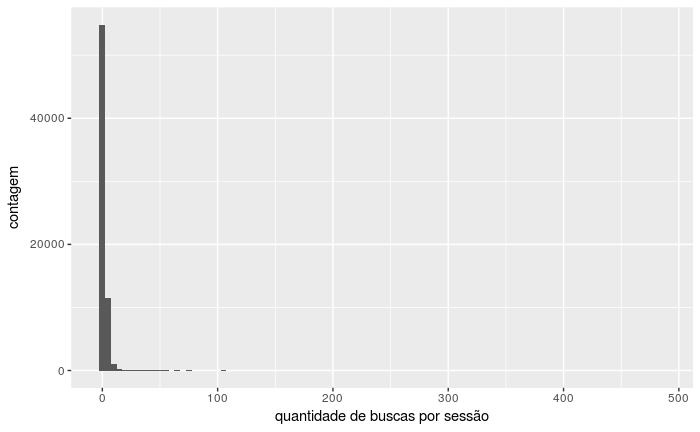

```r
buscas.por.sessao %>%
    ggplot(aes(x = contagem)) +
        geom_histogram(binwidth = 5) +
        labs(x = "quantidade de buscas por sessão", y = "contagem")
```

De um total de quase 68 mil sessões, a maior parte teve até 10 buscas, que estão concentradas nas duas primeiras barras, e a distribuição é bastante assimétrica e enviesada à direita.

Existem 10 sessões com mais de 90 buscas, que parece ser um valor bastante elevado para um humano fazer, porém o tempo mediano e desvio padrão entre consultas não parece ser baixo, como um robô faria. Vejamos qual o tempo mediano entre duas consultas:

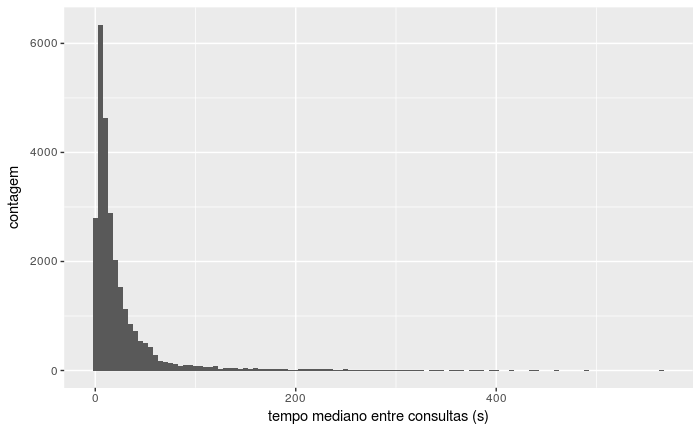

```r
buscas.por.sessao %>%
    filter(!is.na(tempo.mediano.entre.consultas)) %>%
    mutate(tempo.mediano.entre.consultas = as.integer(tempo.mediano.entre.consultas)) %>%
    ggplot(aes(x = tempo.mediano.entre.consultas)) +
        geom_histogram(binwidth = 5) +
        labs(x = "tempo mediano entre consultas (s)", y = "contagem")
```

Vejamos agora o desvio padrão do tempo entre consultas

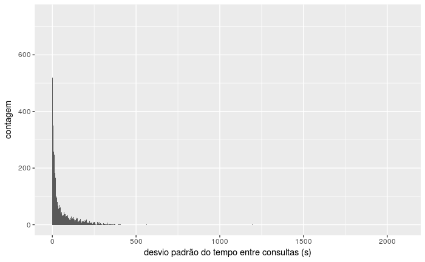

```r
buscas.por.sessao %>%
    filter(!is.na(desvio.padrao.entre.consultas)) %>%
    mutate(desvio.padrao.entre.consultas = as.integer(desvio.padrao.entre.consultas)) %>%
    ggplot(aes(x = desvio.padrao.entre.consultas)) +
        geom_histogram(binwidth = 1) +
        labs(x = "desvio padrão do tempo entre consultas (s)", y = "contagem")
```

Vemos que assim como a mediana, o desvio padrão do tempo entre consultas concentrado em valores baixos, porém tem uma cauda mais longa.

### session_start_date

Vamos explorar agora a data das buscas:

```r
buscas %>%
    summarise(data.inicio = min(session_start_date),
              data.fim = max(session_start_date))
```

| data.inicio | data.fim |
| --- | --- |
| 2016-03-01 00:00:02 | 2016-03-08 20:24:32 |

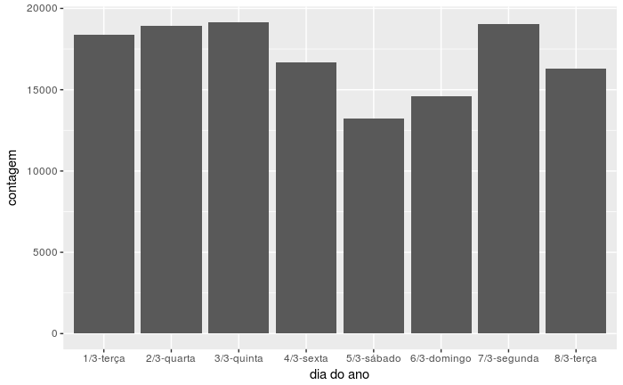

```r
buscas %>%
    mutate(dia.do.ano = paste(day(session_start_date), "/", month(session_start_date), "-", weekdays(session_start_date), sep = "")) %>%
    group_by(dia.do.ano) %>%
    count() %>%
    ggplot(aes(x = dia.do.ano, n)) +
        geom_bar(stat = "identity") +
        labs(x = "dia do ano", y = "contagem")
```

Vemos que os dados vão do dia 01/03/2016 à 08/03/2016, onde os finais de semana tem menos observações que os demais. Como o dia 08/03 foi até as 20h, tem menos observações que os outros dias de semana.

### group

Vejamos agora os grupos que estão presentes nos dados.

```r
buscas %>%
    group_by(group) %>%
    summarise(total = n(),
              proporcao = total / nrow(buscas))
```

| group | total | proporcao |
| --- | --- | --- |
| a | 92056 | 0.6757197 |
| b | 44178 | 0.3242803 |

Vemos que cerca de 70% das buscas são do grupo A, enquanto cerca de 30% são do grupo B.

### results

Vejamos agora quantos resultados as buscas retornam:

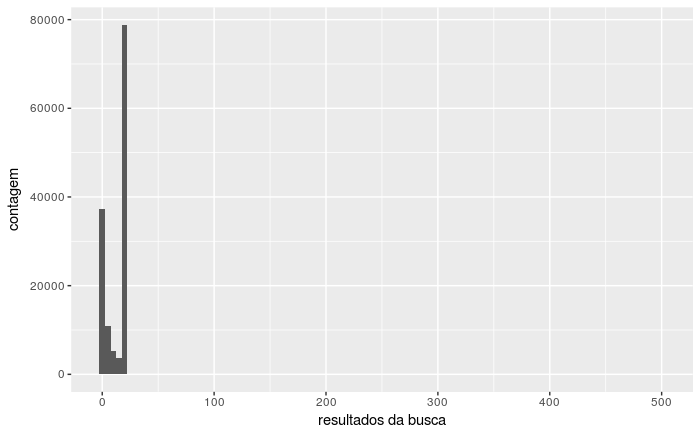

```r
buscas %>%
    ggplot(aes(x = results)) +
        geom_histogram(binwidth = 5) +
        labs(x = "resultados da busca", y = "contagem")
```

A maior parte das buscas retornam até 20 resultados, porém existem alguns que retornam bem mais que este valor. Vejamos quais são estes:

```r
buscas %>%
    filter(results > 20) %>%
    arrange(-results) %>%
    select(session_id, results)
```

| session_id | results |
| --- | --- |
| 03e4e90686ac43fc | 500 |
| 0706006cd5457e53 | 500 |
| 1bbdd282c7c52299 | 500 |
| 1c08a0976e7b3268 | 500 |
| 240b815b8840d794 | 500 |
| 240b815b8840d794 | 500 |
| 240b815b8840d794 | 500 |
| 349b9eaf04abc0cd | 500 |
| 4f7833c7103c698a | 500 |
| 4f7833c7103c698a | 500 |

[output cut: 399 more lines]

Vemos que existe uma quantidade considerável de buscas que retornaram mais que 20 resultados, tendo vários que retornaram até 500. Como a (api)[https://www.mediawiki.org/wiki/API:Lists] informa que o limite de resultados é 10 por default, mas pode ser aumentado até 500, então não faremos nenhum processamento com os resultados.

### num_clicks

Vejamos agora a quantidade de clicks que um usuário faz:

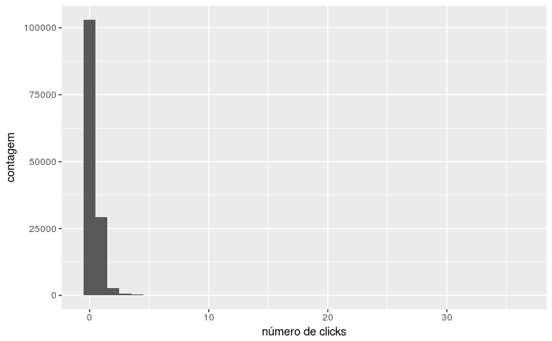

```r
buscas %>%
    ggplot(aes(x = num_clicks)) +
        geom_histogram(binwidth = 1) +
        labs(x = "número de clicks", y = "contagem")
```

Vemos que a concentração maior de clicks está próxima de zero, porém a distribuição tem uma cauda longa a direita, tendo um caso que o usuário clicou mais de 30 vezes nos itens da busca.

Podemos ver abaixo que existem quantidades de clicks superior à quantidade de resultados, inclusive quando a quantidade de resultados é zero. Como um usuário pode clicar em uma página, depois em outra e em seguida voltar à primeira, removeremos apenas as observações que o número de clicks for superior a quantidade de resultados e o número de resultados for zero.

```r
buscas %>%
    filter(num_clicks > results) %>%
    arrange(results) %>%
    select(session_id, num_clicks, results)
```

| session_id | num_clicks | results |
| --- | --- | --- |
| 0c02236a143c5f2d | 1 | 0 |
| 3ed6cf242cfef08e | 3 | 0 |
| 40c841015011ca78 | 1 | 0 |
| 5cd911a51593a318 | 3 | 0 |
| 802227a5617ada1a | 1 | 0 |
| c87ebed483880c25 | 1 | 0 |
| e408f661309b14e5 | 1 | 0 |
| 01a0d2b3d48278a7 | 5 | 1 |
| 02aa6878fcdf6c58 | 3 | 1 |
| 056145b0bb0d8b0a | 2 | 1 |

[output cut: 98 more lines]

```r
buscas.filtradas <- buscas %>%
    filter(!(num_clicks > results & results == 0))
```

### first_click

Vejamos agora a distribuição da posição do item que o usuário clicou no mecanismo de busca:

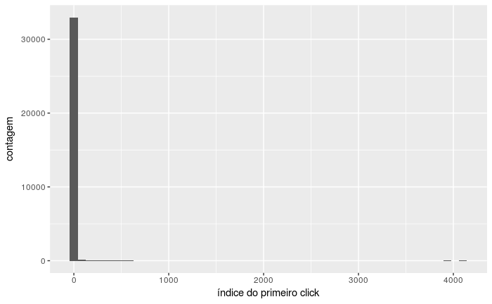

```r
buscas %>%
    filter(!is.na(first_click)) %>%
        ggplot(aes(x = first_click)) +
            geom_histogram(bins = 50) +
            labs(x = "índice do primeiro click", y = "contagem")
```

Vemos que a maior parte dos indices tem valor baixo, mas existem alguns com valor acima de 4000, o que é uma anomalia, visto que vimos anteriormente que as buscas só retornam até cerca de 500 resultados.

Visto isso, vamos remover as buscas que tiverem o índice do primeiro click acima do total de resultados.

```r
buscas.filtradas <- buscas.filtradas %>%
    filter(is.na(first_click) | first_click <= results)
```

### session_length

Por último, veremos quanto tempo demora as sessões, vendo sua distribuição:

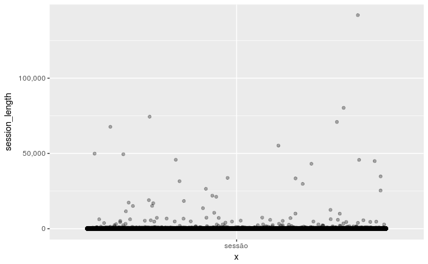

```r
buscas.filtradas %>%
    ggplot(aes(x = "sessão", y = session_length)) +
        geom_jitter(alpha = 0.3) +
        scale_y_continuous(labels = comma)
```

Vemos que grande parte das sessões tem duração baixa, visto a grande concentração de pontos abaixo.

Como a sessão não tem nenhuma restrição, não faremos nenhum filtro com a mesma.

## Respondendo a primeira pergunta

Relembrando, a primeira pergunta a ser respondida é a seguinte: **Qual é nossa taxa de click geral diária? Como ela varia entre os grupos?**

Como alguns dados foram filtrados, vejamos novamente a distribuição da quantidade de clicks:

```r
buscas.filtradas %>%
    ggplot(aes(x = "sessão", y = num_clicks)) +
        geom_jitter(alpha = 0.05) +
        labs(x = "sessão", y = "número de clicks")

buscas.filtradas %>%
    ggplot(aes(x = num_clicks)) +
        geom_histogram(binwidth = 1) +
        labs(x = "número de clicks", y = "contagem")
```

[output not shown]

```r
buscas.filtradas %>%
    pull(num_clicks) %>%
    summary()

buscas.filtradas %>%
    summarise(proporcao.zero.clicks = sum(num_clicks == 0) / n())
```

[output not shown]

Vejamos agora como que a taxa de clicks varia nos grupos:

```r
buscas.filtradas %>%
    ggplot(aes(x = group, y = num_clicks)) +
        geom_jitter(alpha = 0.1) +
        labs(x = "grupo", y = "número de clicks")

buscas.filtradas %>%
    ggplot(aes(x = num_clicks)) +
        geom_histogram(binwidth = 1) +
        facet_grid(group ~ ., scales = "free_y") +
        labs(x = "número de clicks", y = "contagem")
```

[output not shown]

```r
buscas.filtradas %>%
    filter(group == "a") %>%
    pull(num_clicks) %>%
    summary()

buscas.filtradas %>%
    filter(group == "b") %>%
    pull(num_clicks) %>%
    summary()
```

[output not shown]

Com isso concluímos que independente do grupo a taxa de clicks geral é baixa, mas existe uma pequena diferença entre a taxa de clicks do grupo a e do grupo b, sendo a taxa do grupo a um pouco maior que a do b.

## Respondendo a segunda pergunta

Relembrando, a segunda pergunta a ser respondida é a seguinte: **Qual resultados as pessoas tendem a tentar primeiro? Como ela muda dia a dia?**

Para responder esta pergunta veremos primeiramente a distribuição dos valores do índice do primeiro click, para isso, vamos filtrar as observações que informam onde clicaram:

```r
buscas.com.click <- buscas.filtradas %>%
    filter(!is.na(first_click))

buscas.com.click %>%
    ggplot(aes(x = "sessão", y = first_click)) +
        geom_jitter(alpha = 0.3) +
        labs(x = "sessão", y = "índice do primeiro click") +
        scale_y_log10()
```

[output not shown]

Vemos que a maior concentração está em índices baixos, abaixo de 10, como podemos ver no histograma a seguir:

```r
buscas.com.click %>%
    ggplot(aes(x = first_click)) +
        geom_histogram(binwidth = 1) +
        labs(x = "índice do primeiro click", y = "contagem")
```

[output not shown]

```r
buscas.com.click %>%
    pull(first_click) %>%
    summary()
```

[output not shown]

Vejamos agora como que as buscas mudam dia a dia.

```r
buscas.com.click %>%
    mutate(dia.do.ano = paste(day(session_start_date), "/", month(session_start_date), "-", weekdays(session_start_date), sep = "")) %>%
    ggplot(aes(x = first_click)) +
        geom_histogram(binwidth = 1) +
        facet_grid(dia.do.ano ~ .) +
        labs(x = "índice do primeiro click", y = "contagem") +
        theme_bw()
```

[output not shown]

As distribuições dos clicks parecem seguir a mesma distribuição, independente do dia da semana, como podemos confirmar com as médias, medianas e proporção de clicks no primeiro link, visto abaixo.

```r
buscas.com.click %>%
    mutate(dia.do.ano = paste(day(session_start_date), "/", month(session_start_date), "-", weekdays(session_start_date), sep = "")) %>%
    group_by(dia.do.ano) %>%
    summarise(
        media = mean(first_click),
        mediana = median(first_click),
        proporcao.de.1 = sum(first_click == 1) / n()
    ) %>%
    gather(medida, valor, -dia.do.ano) %>%
    ggplot(aes(x = dia.do.ano, y = valor, fill = medida)) +
        geom_bar(stat = "identity") +
        facet_grid(medida ~ ., scales = "free") +
        theme(axis.text.x = element_text(angle = -45, hjust = 0)) +
        labs(x = "dia do ano")
```

[output not shown]

## Respondendo a terceira pergunta

Relembrando, a terceira pergunta a ser respondida é a seguinte: **Qual é nossa taxa de resultados zerados diária? Como ela varia entre os grupos?**

Vejamos a distribuição da quantidade dos resultados:

```r
buscas.filtradas %>%
    ggplot(aes(x = "sessão", y = results)) +
        geom_boxplot() +
        labs(x = "sessão", y = "quantidade de resultados")

buscas.filtradas %>%
    pull(results) %>%
    summary()
```

[output not shown]

Vejamos a taxa de resultados zerados diária:

```r
buscas.filtradas %>%
    mutate(dia.do.ano = paste(day(session_start_date), "/", month(session_start_date), "-", weekdays(session_start_date), sep = "")) %>%
    group_by(dia.do.ano) %>%
    summarise(prop.de.zero = sum(results == 0) / n()) %>%
    ggplot(aes(x = dia.do.ano, y = prop.de.zero)) +
        geom_bar(stat = "identity") +
        labs(x = "dia", y = "proporção de zeros")
```

[output not shown]

Vejamos se a taxa de resultados zerados diária muda de acordo com o grupo:

```r
buscas.filtradas %>%
    group_by(group) %>%
    summarise(prop.de.zero = sum(results == 0) / n()) %>%
    ggplot(aes(x = group, y = prop.de.zero, fill = group)) +
        geom_bar(stat = "identity")
```

[output not shown]

Apesar de não existir quase diferença entre a proporção dos resultados zerados diários, como vemos acima, ao variarmos no dia, parece haver uma ligeira diferença entre os grupos com relação a proporção de zeros no sábado e domingo, onde a proporção é maior para o grupo b.

```r
buscas.filtradas %>%
    mutate(dia.do.ano = paste(day(session_start_date), "/", month(session_start_date), "-", weekdays(session_start_date), sep = "")) %>%
    group_by(dia.do.ano, group) %>%
    summarise(prop.de.zero = sum(results == 0) / n()) %>%
    ggplot(aes(x = dia.do.ano, y = prop.de.zero, fill=group)) +
        geom_bar(stat = "identity", position = "dodge") +
        labs(x = "dia", y = "proporção de zeros")
```

[output not shown]

## Respondendo a quarta pergunta

Relembrando, a quarta e última pergunta a ser respondida é a seguinte: **Seja duração da sessão aproximadamente o tempo entre o primeiro evento e o último evento em uma sessão. Escolha uma variável dos dados e descreva seu relacionamento com a duração da sessão. Visualiza o relacionamento.**

Vamos agora verificar a relação entre a duração da sessão e o número de clicks, visto que parece fazer sentido uma pessoa que passou muito tempo no sistema de busca, clicar em mais itens.

Vejamos abaixo se existe relação entre as variáveis:

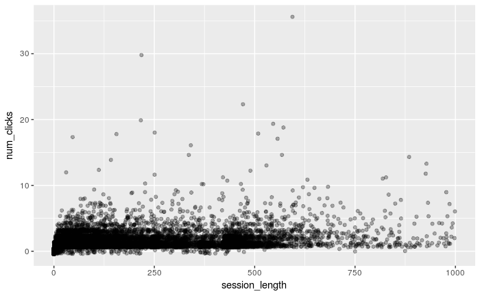

Podemos ver que existem muitos pontos concentrados no canto esquerdo, visto que é mais comum ter sessões curtas, além de existir alguns pontos quase paralelos ao eixo horizontal, formando um “L”.

Desta forma, concluímos que não parece existir relação significativa entre as variáveis da duração da sessão e do número de clicks, como podemos ver abaixo pela correlação de pearson:

| correlacao |
| --- |
| 0.1098683 |